# Homework 3 - 3

Xuechun Wang

5/5/2020

# Problem 3

## Part A:

Use the log-returns data from Homework 1 and 2, and apply the **fsInf** and **fixedLassoInf** function from the **selectiveInference** R package to perform inference for forward stepwise regression and LASSO. For the **fixedLassoInf** function, use $\lambda.\min$ obtained from the **cv.glmnet** function from the **glmnet** R package. Compare and contrast the results from these two methods for inference.

```r
require(selectiveInference)
library(umap)
library(Rtsne)
logreturn = read.csv("data_new.csv",header = F)
col = ncol(logreturn)
lr_x = logreturn[, 2:251]
lr_y = logreturn[,252]

# forward stepwise regression and LASSO
# forward stepwise
y_finance = as.numeric(lr_y)
X_finance = as.matrix(lr_x)

# forward step
fsfit_finance = fs(X_finance, y_finance)

# fsInf: compute sequential p-values and confidence intervals
out_finance.seq = fsInf(fsfit_finance)
out_finance.seq
```

```
##
## Call:
## fsInf(obj = fsfit_finance)
##
## Standard deviation of noise (specified or estimated) sigma = 12.463
##
## Sequential testing results with alpha = 0.100
##  Step Var   Coef Z-score P-value LowConfPt UpConfPt LowTailArea UpTailArea
##     1 227  1.101  20.027   0.000     1.009    1.192       0.049      0.049
##     2 193  0.535   0.973   0.897      -Inf    3.509       0.000      0.050
##     3 183  0.315   0.640   0.771      -Inf   36.370       0.000      0.050
##     4 118  0.279   0.457   0.160   -11.208      Inf       0.050      0.000
##     5 101  0.216   0.314   0.982      -Inf  -15.303       0.000      0.050
##     6 247  0.164   0.307   0.262      -Inf      Inf       0.000      0.000
##     7 109 -0.179  -0.305   0.811   -14.922      Inf       0.050      0.000
```

[output cut: 245 more lines]

```r
cat('Number of coeffients left:', length(out_finance.seq$pv), '\n\n')
```

```
## Number of coeffients left: 250
```

```r
out_finance.seq$pv
```

```
##   [1] 9.488222e-29 8.974890e-01 7.714380e-01 1.598065e-01 9.815170e-01
##   [6] 2.615250e-01 8.109544e-01 3.594938e-01 3.802032e-01 6.063656e-01
##  [11] 2.346567e-01 6.392351e-01 7.488473e-01 9.943024e-01 3.125303e-02
##  [16] 3.737472e-01 7.923863e-01 3.584571e-01 4.304530e-01 8.273784e-01
##  [21] 3.184119e-01 3.636674e-01 8.464837e-01 5.150029e-01 3.220726e-01
##  [26] 2.120765e-01 5.041630e-01 7.025617e-01 8.000618e-01 2.592983e-01
##  [31] 6.060109e-01 7.804689e-01 9.680438e-01 8.560108e-01 2.121724e-01
##  [36] 4.943354e-01 6.187942e-01 2.357756e-01 4.737092e-01 6.520839e-01
##  [41] 6.788697e-01 7.206464e-01 3.854457e-01 7.398388e-01 7.648939e-01
##  [46] 7.960938e-01 6.714288e-02 5.566029e-01 9.252388e-01 5.090577e-02
##  [51] 2.139324e-01 4.503633e-01 4.724075e-01 9.230162e-01 3.136833e-01
##  [56] 4.202164e-02 2.321583e-01 6.274376e-01 7.072431e-01 5.316395e-01
##  [61] 7.527623e-01 3.655699e-01 1.408680e-01 9.417928e-01 1.700078e-01
##  [66] 4.488647e-01 9.277718e-01 9.944568e-01 5.316436e-01 1.960562e-02
##  [71] 4.698047e-01 9.382149e-02 9.774525e-01 1.218312e-01 3.068497e-01
```

[output cut: 35 more lines]

```r
# lambda min from glmnet
glmnet_cv_finance = cv.glmnet(X_finance, y_finance, thresh = 1e-07)

n_finance = nrow(X_finance)
lambda_finance = n_finance*glmnet_cv_finance$lambda.min
cat('lambda.min =', lambda_finance, '\n')
```

```
## lambda.min = 30.11153
```

```r
# Find all betas
gfit_finance = glmnet(X_finance, y_finance, standardize = FALSE)
bhat_finance = coef(gfit_finance, x = X_finance, y = y_finance, s = lambda_finance/n_finance, exact = TRUE)[-1]

# fit fixedLassoInf
fix_lasso_fin = fixedLassoInf(X_finance, y_finance, bhat_finance, lambda_finance)
fix_lasso_fin
```

```
##
## Call:
## fixedLassoInf(x = X_finance, y = y_finance, beta = bhat_finance,
##     lambda = lambda_finance)
##
## Standard deviation of noise (specified or estimated) sigma = 12.463
##
## Testing results at lambda = 30.112, with alpha = 0.100
##
##  Var   Coef Z-score P-value LowConfPt UpConfPt LowTailArea UpTailArea
##    5  0.053   0.071       1      -Inf  -74.282           0          0
##   38  0.063   0.086       1      -Inf  -72.927           0          0
##   44  0.035   0.042       1      -Inf  -83.324           0          0
##   51 -0.080  -0.113       1    71.124      Inf           0          0
##   64  0.068   0.088       1      -Inf  -77.563           0          0
```

[output cut: 36 more lines]

```r
cat('Number of coeffients left:', length(fix_lasso_fin$pv), '\n\n')
```

```
## Number of coeffients left: 39
```

```r
fix_lasso_fin$pv
```

```
##  [1] 1 1 1 1 1 1 1 1 1 1 1 1 1 1 1 1 1 1 1 1 1 1 1 1 1 1 1 1 1 1 1 1 1 1 1
## [36] 1 1 1 1
```

We can see that fsInf method doesn’t penalize any variable coefficient to 0. However, fixedLassoInf penalized the variables and only leaves with us less variables. This will make it easier for inference the result, since we have less variables. In addition, the fsInf gives movre coefficents with p value smaller than 0.05 compared to fixedLassoInf.

## Part B:

Use UMAP to visualize the relationships between the log-returns of the symbols over the year. Be sure to first standardize each symbol, and explain what you observe.– that is, visualize the patients and also the gene expressions across the patients. Do this for the raw data, and also for the data after standardization of the variables. Compare this embeddings with embedding from $t$-SNE.

### UMAP

#### Before Standardlization

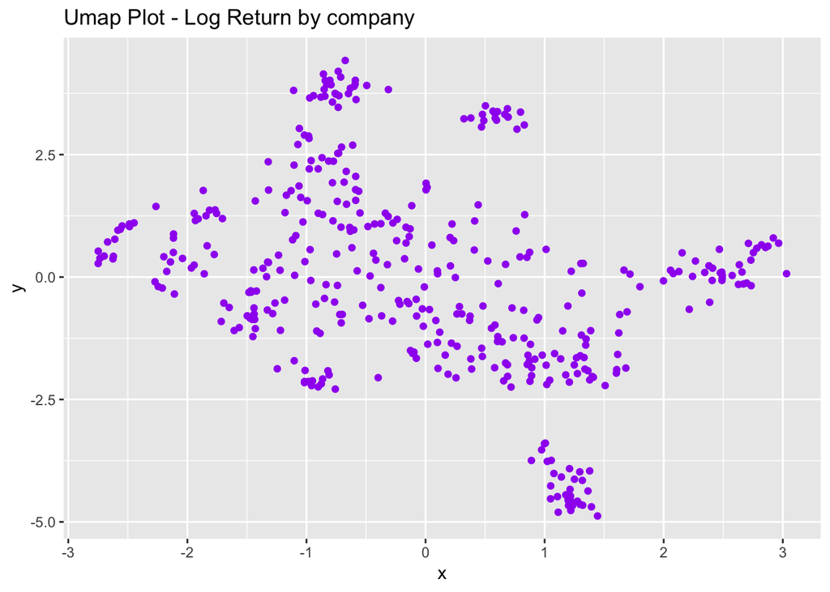

```r
set.seed(666)
library(ggplot2)
embedding = umap(X_finance)

df <- data.frame(x = embedding$layout[,1],
                 y = embedding$layout[,2])

# visualize the gene expressions
p = ggplot(df, aes(x = x, y= y)) + geom_point(color = "purple")
p+ggtitle("Umap Plot - Log Return by company")
```

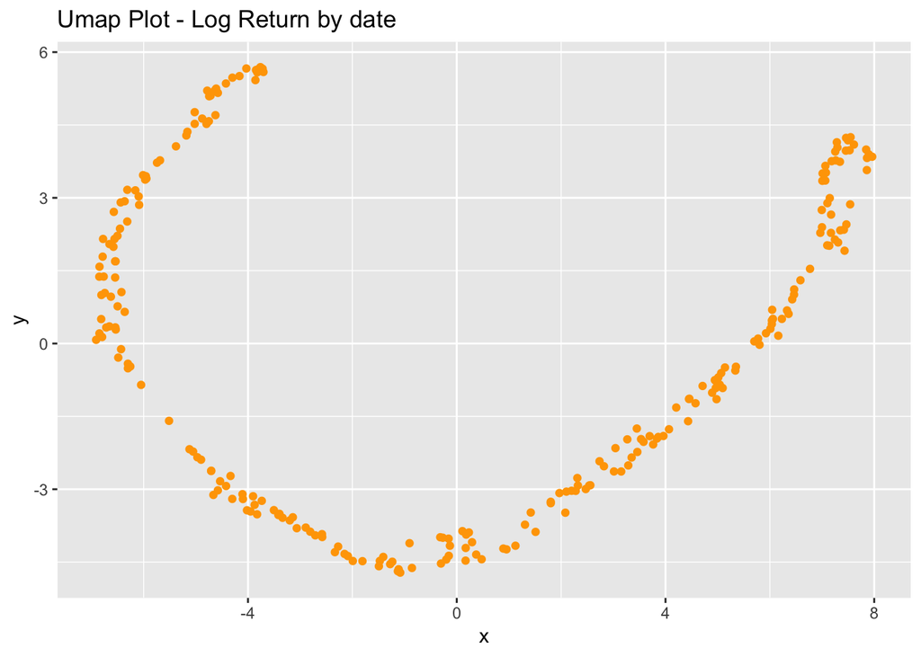

```r
set.seed(666)
embedding = umap(t(X_finance))

df <- data.frame(x = embedding$layout[,1],
                 y = embedding$layout[,2])

# visualize the gene expressions
p = ggplot(df, aes(x = x, y= y)) + geom_point(color = "orange")
p+ggtitle("Umap Plot - Log Return by date")
```

#### After Standardlization

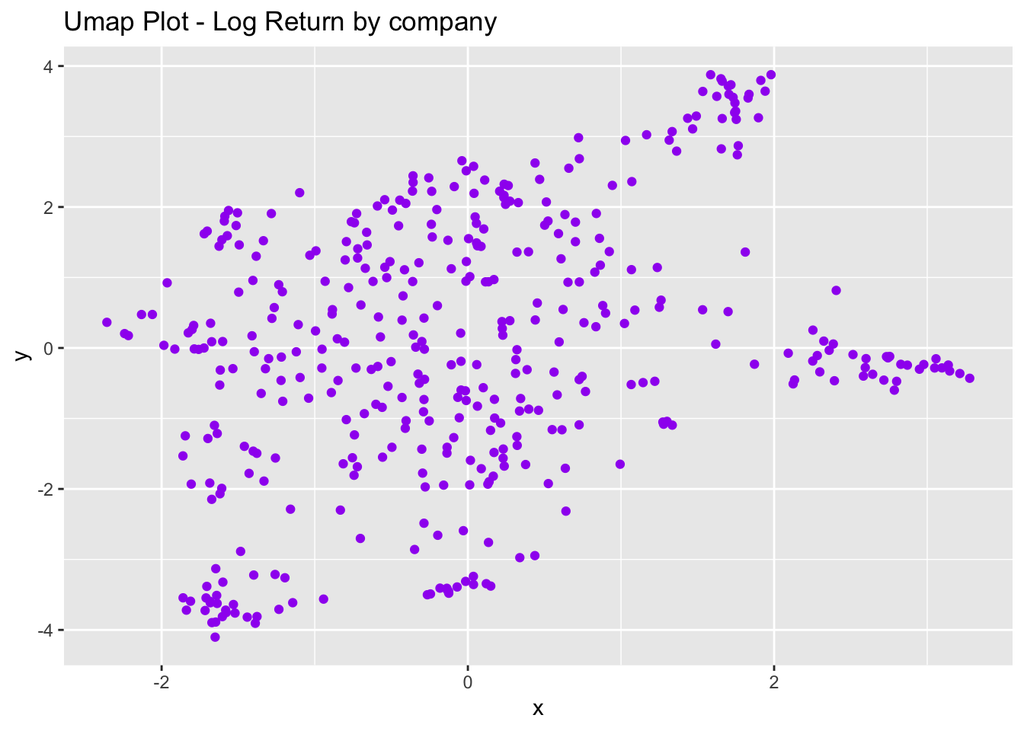

```r
set.seed(666)
scaled_lrx = scale(X_finance,center = T,scale = T)
embedding = umap(scaled_lrx)

df <- data.frame(x = embedding$layout[,1],
                 y = embedding$layout[,2])

# visualize the gene expressions
p = ggplot(df, aes(x = x, y= y)) + geom_point(color = "purple")
p+ggtitle("Umap Plot - Log Return by company")
```

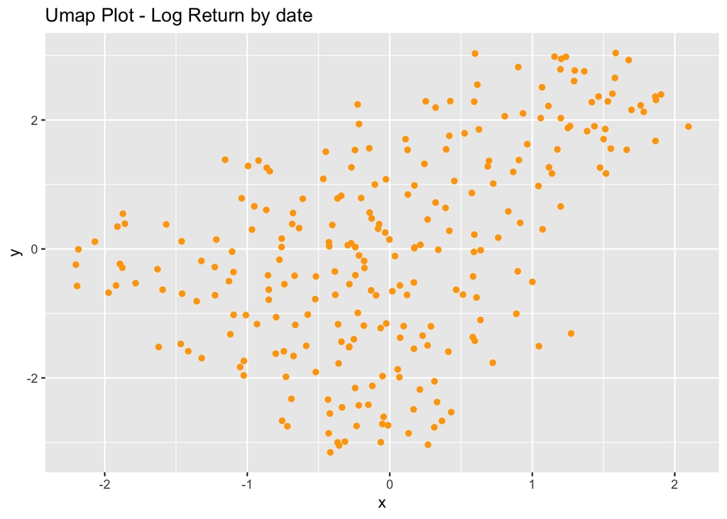

```r
set.seed(666)
scaled_lrx_t = scale(t(X_finance),center = T,scale = T)
embedding = umap(scaled_lrx_t)

df <- data.frame(x = embedding$layout[,1],
                 y = embedding$layout[,2])

# visualize the gene expressions
p = ggplot(df, aes(x = x, y= y)) + geom_point(color = "orange")
p+ggtitle("Umap Plot - Log Return by date")
```

### t-SNE

#### Before Standardlization

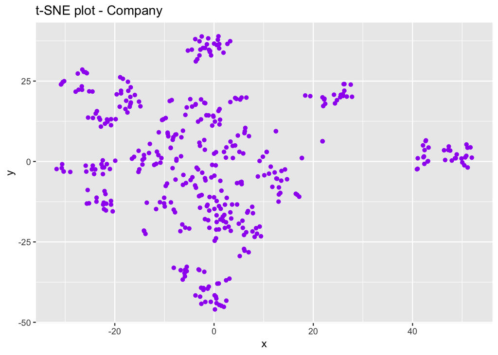

```r
tsne_gene = Rtsne(X_finance, perplexity = 6)
df3 = data.frame(x = tsne_gene$Y[,1],
                 y = tsne_gene$Y[,2])

ggplot(df3, aes(x, y)) + geom_point(color = "purple") + ggtitle("t-SNE plot - Company ")
```

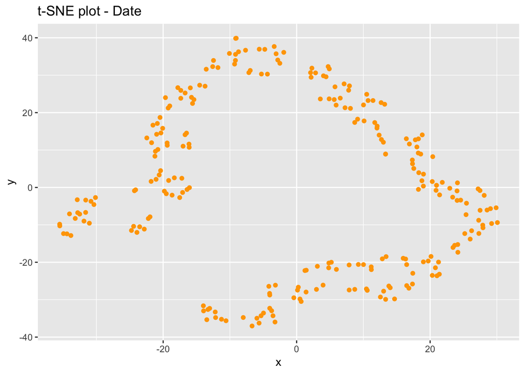

```r
tsne_gene = Rtsne(t(X_finance), perplexity = 6)
df3 = data.frame(x = tsne_gene$Y[,1],
                 y = tsne_gene$Y[,2])

ggplot(df3, aes(x, y)) + geom_point(color = "orange") + ggtitle("t-SNE plot - Date")
```

#### After Standardlization

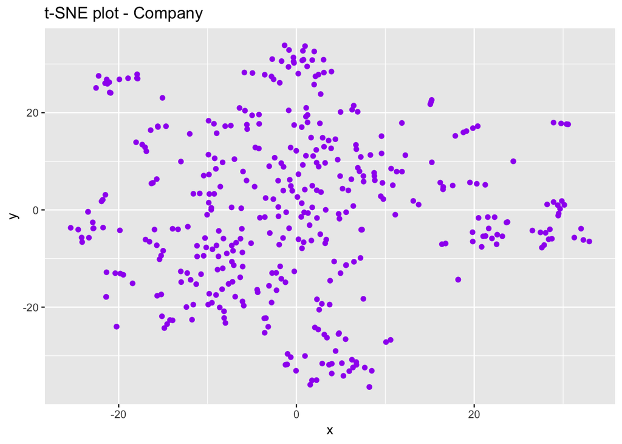

```r
tsne_gene = Rtsne(scaled_lrx, perplexity = 6)
df3 = data.frame(x = tsne_gene$Y[,1],
                 y = tsne_gene$Y[,2])

ggplot(df3, aes(x, y)) + geom_point(color = "purple") + ggtitle("t-SNE plot - Company")
```

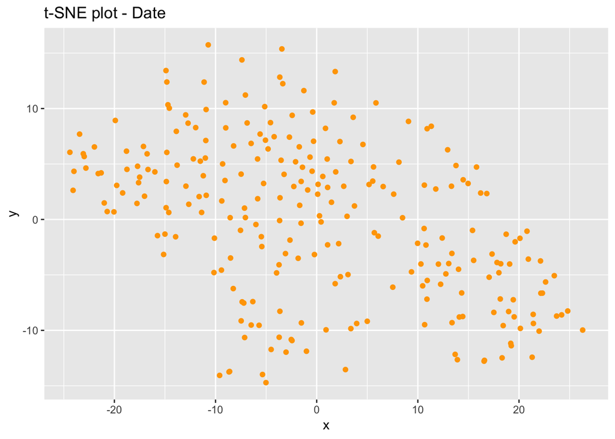

```r
tsne_gene = Rtsne(scaled_lrx_t, perplexity = 6)
df3 = data.frame(x = tsne_gene$Y[,1],
                 y = tsne_gene$Y[,2])

ggplot(df3, aes(x, y)) + geom_point(color = "orange") + ggtitle("t-SNE plot - Date")
```

## Part C:

For each of the symbols from the S&P 500 log-returns data, use the **trendfilter** function from the **genlasso** R package with **ord=3** to fit a regularized function to the daily log-returns data for the year. Describe what type of model selection this function is doing, and explain what you observe for your results.

```r
library(genlasso)
```

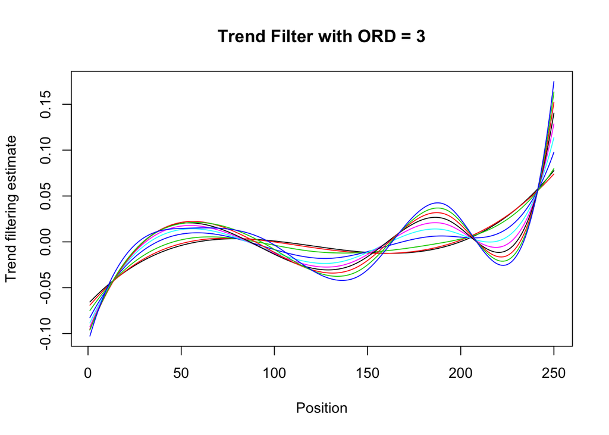

```r
fit = trendfilter(y = y_finance, X = X_finance, ord = 3)
plot(fit, main = "Trend Filter with ORD = 3")
```

From the above plot we can see that despite what we have at the begining or the middle or the order, the data that has the larger position would be more important and thus have higher trend filtering estimates.